# Introduction to scikit-learn

- Adapted from the scikit-learn tutorial and user guide at http://scikit-learn.org/.

> Panos Louridas, Associate Professor  
> Department of Management Science and Technology  
> Athens University of Economics and Business  
> louridas@aueb.gr

# Machine Learning

- Machine Learning is the area of Computer Science that seeks to find ways so that computer can learn by themselves, without us having to program them.
- There are three main areas:
  - Supervised learning
  - Unsupervised learning
  - Reinforcement learning

# Supervised Learning

- In supervised learning, we give the computer a set of *example problems* along with their *solutions*.
- The computer must then find the way so that given new problems, that it has not seen before, it can find their solutions.
- We therefore start with a *training* phase. After that we go to a *testing* phase, where we use the trained computer against some holdout data, to check its perfomance. Then we can go to production.
- Examples of supervised learning:
  - Classification
  - Decision trees
  - Bayesian networks
  - Artificial neural networks
  - ...

# Support Vector Machines

- Support Vector Machines (SVM) is an approach to classification developed in the 1990s.
- It is very popular, so it is a good vehicle to start exploring Machine Learning.
- To see what they are, we must talk about *Maximal Margin Classifiers* and *Support Vector Classifiers*.

# Maximal Margin Classifiers

- We want to separate our observations into two classes.
- If our observations have $p$ features, or dimensions, they can be separated by a $p-1$ dimensional hyperplane.
- We try to find the best hyperplane.
- We compute the perpendicular distance from each observation to the candidate hyperplane. The smallest of these distances is called the *margin*.
- We select the hyperplane with the maximal margin.
- The mathematical formulation is: $$\text{maximimize } M(\beta_0, \beta_1, \beta_p)$$ subject to: $$\sum_{j=1}^{p}{\beta_j^2 = 1}$$ $$y_i(\beta_0 + \beta_1 x_{i1} + \beta_2 x_{i2} + \ldots + \beta_p x_{ip}) \ge M$$ for $i = 1, 2, \ldots, n$ and $y \in \{-1 , +1\}$.
- In the following slide you can see three different hyperplanes and two different classes.
- $\textrm{H}_1$ does not separate the black class.
- $\textrm{H}_2$ and $\textrm{H}_3$ both separate the two classes.
- $\textrm{H}_3$ does a better job, because it separates the classes with a wider margin.

[figure not shown]

# Support Vector Classifiers

- Support Vector Classifiers are a generalisation of Maximal Margin Classifiers.
- Instead of trying to find the biggest margin, it allows some observations to lie on the wrong side of the margin, even on the wrong side of the hyperplane.
- In this we achieve greater robustness to invividual observations and better classification of most of the observations.
- The mathematical formulation is: $$\text{maximimize } M(\beta_0, \beta_1, \beta_p)$$ subject to: $$\sum_{j=1}^{p}{\beta_j^2 = 1}$$ $$y_i(\beta_0 + \beta_1 x_{i1} + \beta_2 x_{i2} + \ldots + \beta_p x_{ip}) \ge (M - \epsilon_i)$$ $$ \epsilon_i \ge 0$$ $$ \sum_{i=1}^{n}\epsilon_i \le C$$ for $i = 1, 2, \ldots, n$ and $y \in \{-1 , +1\}$.
- Note that if $\epsilon_i = 0$, then the $i$th observation lies on the correct side of the hyperplane.
- If $C = 0$, there can be no violations.
- If $C > 0$, then no more than $C$ observations can be on the wrong side of the hyperplane (if an observation is on the wrong side, then $\epsilon_i > 1$).
- The observations that lie on the margin, or on the wrong side of the margin are called *support vectors*, because they affect the classifier (the rest *do not*).

# Support Vector Machines

- Support Vector Machines are a generalisation of Support Vector Classifiers.
- Instead of trying to find the biggest margin, it allows some observations to lie on the wrong side of the margin, even on the wrong side of the hyperplane.
- In this we achieve greater robustness to invividual observations and better classification of most of the observations.
- It can be shown that the Support Vector Classifier can be represented as: $$ f(x) = \beta_0 + \sum_{i = 1}^{n}\alpha_i\langle x, x_i \rangle$$ for $n$ parameters $a\_i$, one per training observation.
- To estimate the parameters we work with the inner products $\langle x_i, x_i'\rangle$ between any pair $x_i, x_i'$ of training observations.
- Now we generalize, and we allow ourselves to use other functions, and not just inner products.
- So we have: $$ f(x) = \beta_0 + \sum_{i = 1}^{n}\alpha_i K(x, x_i) $$
- $K(\cdot, \cdot)$ is called a *kernel*.
- If $K(x_i, x_j) = \sum_{i = 1}^n x_{ij}x_{i'j}$, then we have an inner product, which is a linear kernel, and so we get a Support Vector Classifier.
- But if $K(\cdot, \cdot)$ is not linear in the features, we get a Support Vector Machine.
- Support Vector Machines can classify observations that are not linear separable.
- Common kernels are:
  - linear: $\langle x, x'\rangle$.
  - polynomial: $(\gamma \langle x, x'\rangle + r)^d$
  - radial: $\exp(-\gamma |x-x'|^2)$.
  - sigmoid: $\tanh(\gamma \langle x,x'\rangle + r)$

# SVMs with Many Classes

- If we have more than two classes, we can work with the following strategies:
  - One-versus-One Classification
  - One-versus-All Classification

## One-versus-One Classification

- In One-versus-One (OvO) classification for $K$ classes, we create $\binom{K}{2} = \frac{K(K-1)}{2}$ SVMs.
- Each one of them classifies observation for a distinct pair of classes.
- We tally the classes assigned for each observation.
- In the end, we assign to each observation the class with the maximum tally.

## One-versus-All Classification

- In One-versus-All (OvA) a.k.a. One-versus-Rest (OvR) classification for $K$ classes, we create $K$ SVMs.
- In each one of them, we classify observations in one class versus all the other $K - 1$ classes lumped together.
- In the end, we assign to each observation the class with the maximum distance from the hyperplane.

[figure not shown]

# Scikit-learn

- scikit-learn is a Machine Learning toolkit in Python.
- In their own words:
  - It started in 2007 as a Google Summer of Code project by David Cournapeau. Later that year, Matthieu Brucher started work on this project as part of his thesis.
  - In 2010 Fabian Pedregosa, Gael Varoquaux, Alexandre Gramfort and Vincent Michel of INRIA took leadership of the project and made the first public release, February the 1st 2010. Since then, several releases have appeared following a ~3 month cycle, and a thriving international community has been leading the development.

```python
import sklearn as sk
import numpy as np
import matplotlib.pyplot as plt

%matplotlib inline
```

# A Short Example

- We'll build a classifier for handwritten digits.
- We won't go into many details at this point; we just want to get an overview of scikit-learn.
- scikit-learn comes with a number of datasets that we can use to get familiar with it.
- A dataset is a dictionary-like object that holds all the data and some metadata about the data.
- This data is stored in the `data` member, which is a `n_samples`, `n_features` array.
- In the case of supervised problem, one or more response variables are stored in the `target` member.

```python
from sklearn import datasets

digits = datasets.load_digits()

print(digits.data.shape)
digits.data
```

```
(1797, 64)
```

```
array([[  0.,   0.,   5., ...,   0.,   0.,   0.],
       [  0.,   0.,   0., ...,  10.,   0.,   0.],
       [  0.,   0.,   0., ...,  16.,   9.,   0.],
       ...,
       [  0.,   0.,   1., ...,   6.,   0.,   0.],
       [  0.,   0.,   2., ...,  12.,   0.,   0.],
       [  0.,   0.,  10., ...,  12.,   1.,   0.]])
```

- In the case of the digits, each original sample is an image of shape (8, 8) and can be accessed using `digits.images[0]`.

```python
print(digits.images.shape)
digits.images[0]
```

```
(1797, 8, 8)
```

```
array([[  0.,   0.,   5.,  13.,   9.,   1.,   0.,   0.],
       [  0.,   0.,  13.,  15.,  10.,  15.,   5.,   0.],
       [  0.,   3.,  15.,   2.,   0.,  11.,   8.,   0.],
       [  0.,   4.,  12.,   0.,   0.,   8.,   8.,   0.],
       [  0.,   5.,   8.,   0.,   0.,   9.,   8.,   0.],
       [  0.,   4.,  11.,   0.,   1.,  12.,   7.,   0.],
       [  0.,   2.,  14.,   5.,  10.,  12.,   0.,   0.],
       [  0.,   0.,   6.,  13.,  10.,   0.,   0.,   0.]])
```

- In the case of the digits dataset, the task is to predict, given an image, which digit it represents.
- We are given samples of each of the 10 possible classes (the digits zero through nine) on which we fit an estimator to be able to predict the classes to which unseen samples belong.
- In scikit-learn, an estimator for classification is a Python object that implements the methods `fit(X, y)` and `predict(T)`.
- An example of an estimator is the class `sklearn.svm.SVC` that implements support vector classification. The constructor of an estimator takes as arguments the parameters of the model.
- Note that `SVC` is hard to scale in samples larger that 10,000.
- The `sklearn.svm.SVC` class uses as a default a [radial basis function](https://en.wikipedia.org/wiki/Radial_basis_function_kernel) kernel.
- The available choices are:
  - `linear`: $\langle x, x'\rangle$.
  - `poly`: $(\gamma \langle x, x'\rangle + r)^d$. $d$ is specified by the `degree` keyword, $r$ by the `coef0` keyword.
  - `rbf`: $\exp(-\gamma |x-x'|^2)$. $\gamma$ is specified by the gamma keyword, must be greater than 0.
  - `sigmoid`: $\tanh(\gamma \langle x,x'\rangle + r)$, where $r$ is specified by the `coef0` keyword.
- Let us create a classification.
- It will use the default, radial, kernel.
- We'll set $\gamma = 0.001$ and the penalty term $C = 100$.

```python
from sklearn import svm
clf = svm.SVC(gamma=0.001, C=100.)
```

- We call our estimator instance `clf`, as it is a classifier.
- It now must be fitted to the model, that is, it must *learn* from the model.
- This is done by passing our training set to the `fit` method.
- As a training set, let us use all the images of our dataset apart from the last one.
- We select this training set with the `[:-1]` Python syntax, which produces a new array that contains all but the last entry of `digits.data`.

```python
clf.fit(digits.data[:-1], digits.target[:-1])
```

```
SVC(C=100.0, cache_size=200, class_weight=None, coef0=0.0,
  decision_function_shape=None, degree=3, gamma=0.001, kernel='rbf',
  max_iter=-1, probability=False, random_state=None, shrinking=True,
  tol=0.001, verbose=False)
```

- `cache_size`: the cache used for the kernel function (in MB).
- `class_weight`: use a weight of one for all classes, or adjust weights inversely proportional to class frequencies in the input data.
- `coef0`: independent term in `poly` and `sigmoid` kernel functions.
- `decision_function_shape`: `ovo` or `ovr`, default is `None`, which currently sets `ovo` (but will change to `ovr` in version 0.19).
- `degree`: degree of the polynomial kernel.
- `gamma`: kernel coefficient for `rbf`, `poly` and `sigmoid`.
- `kernel`: kernel type; default is `rbf`.
- `max_iter`: hard limits of itereations or -1 for no limit.
- `probability`: whether to enable probability estimates.
- `random_state`: seed.
- `shrinking`: whether to use the shrinking heuristic; see [Support Vector Machine Solvers](http://leon.bottou.org/publications/pdf/lin-2006.pdf).
- Now we can predict new values.
- In particular, we can ask to the classifier what is the digit of our last image in the digits dataset, which we have not used to train the classifier.

```python
clf.predict(digits.data[-1:])
```

```
array([8])
```

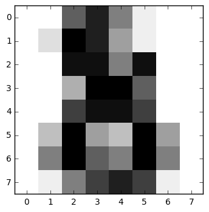

```python
import matplotlib.pyplot as plt

plt.imshow(digits.images[-1], cmap=plt.cm.gray_r, interpolation='nearest')
```

- Let's take this a bit further.
- Suppose that we only had the `digits.images` array.
- We can see the first four images.

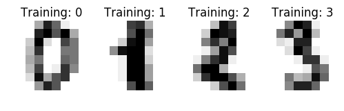

```python
# Author: Gael Varoquaux <gael dot varoquaux at normalesup dot org>
# License: BSD 3 clause

images_and_labels = list(zip(digits.images, digits.target))
for index, (image, label) in enumerate(images_and_labels[:4]):
    plt.subplot(1, 4, index + 1)
    plt.axis('off')
    plt.imshow(image, cmap=plt.cm.gray_r, interpolation='nearest')
    plt.title('Training: %i' % label)
```

- To apply a classifier on this data, we need to flatten the image, to turn the data in a `(samples, feature)` matrix.
- We'll use the `numpy.reshape` method. Note that one shape dimension can be -1. In this case, the value is inferred from the length of the array and remaining dimensions.

```python
n_samples = len(digits.images)
data = digits.images.reshape((n_samples, -1))
```

- Then we'll create a classifier.
- The classifier will be a support vector classifier.

```python
classifier = svm.SVC(gamma=0.001)
```

- We learn the digits on the first half of the digits.

```python
half_samples = int(n_samples / 2)

classifier.fit(data[:half_samples], digits.target[:half_samples])
```

```
SVC(C=1.0, cache_size=200, class_weight=None, coef0=0.0,
  decision_function_shape=None, degree=3, gamma=0.001, kernel='rbf',
  max_iter=-1, probability=False, random_state=None, shrinking=True,
  tol=0.001, verbose=False)
```

- We now predict the value of the digit on the second half.

```python
expected = digits.target[half_samples:]
predicted = classifier.predict(data[half_samples:])
```

- We can plot the predictions, or some of them, to see how they fare.

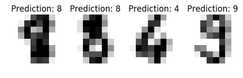

```python
images_and_predictions = list(zip(digits.images[half_samples:], predicted))
for index, (image, prediction) in enumerate(images_and_predictions[:4]):
    plt.subplot(1, 4, index + 1)
    plt.axis('off')
    plt.imshow(image, cmap=plt.cm.gray_r, interpolation='nearest')
    plt.title('Prediction: %i' % prediction)
```

- Apart from visual inspection, we can evaluate our classifier with more formal methods.
- We will explain them a bit later on, for now let's just have a look at them.

```python
from sklearn import metrics

print("Classification report for classifier %s:\n%s\n"
      % (classifier, metrics.classification_report(expected, predicted)))
print("Confusion matrix:\n%s" % metrics.confusion_matrix(expected, predicted))
```

```
Classification report for classifier SVC(C=1.0, cache_size=200, class_weight=None, coef0=0.0,
  decision_function_shape=None, degree=3, gamma=0.001, kernel='rbf',
  max_iter=-1, probability=False, random_state=None, shrinking=True,
  tol=0.001, verbose=False):
             precision    recall  f1-score   support

          0       1.00      0.99      0.99        88
          1       0.99      0.97      0.98        91
          2       0.99      0.99      0.99        86
          3       0.98      0.87      0.92        91
          4       0.99      0.96      0.97        92
          5       0.95      0.97      0.96        91
          6       0.99      0.99      0.99        91
          7       0.96      0.99      0.97        89
          8       0.94      1.00      0.97        88
          9       0.93      0.98      0.95        92

avg / total       0.97      0.97      0.97       899


Confusion matrix:
[[87  0  0  0  1  0  0  0  0  0]
 [ 0 88  1  0  0  0  0  0  1  1]
 [ 0  0 85  1  0  0  0  0  0  0]
 [ 0  0  0 79  0  3  0  4  5  0]
 [ 0  0  0  0 88  0  0  0  0  4]
 [ 0  0  0  0  0 88  1  0  0  2]
 [ 0  1  0  0  0  0 90  0  0  0]
 [ 0  0  0  0  0  1  0 88  0  0]
 [ 0  0  0  0  0  0  0  0 88  0]
 [ 0  0  0  1  0  1  0  0  0 90]]
```

# Linear Classification

- We will try to predict the Iris ower species using only two attributes: sepal width and sepal length.
- This is an instance of a classification problem, where we want to assign a label (a value taken from a discrete set) to an item according to its features.
- To carry out the classification we will use the `SGDClassifier`.
- SGD stands for *Stochastic Gradient Descent*. This is a numerical procedure to find the minimum of a function.
- In our case it will find the minimum of the loss function, which measures how far every data instance is from the classification boundary.
- The advantages of Stochastic Gradient Descent are:
  - Efficiency.
  - Ease of implementation (lots of opportunities for code tuning).
- The disadvantages of Stochastic Gradient Descent include:
  - SGD requires a number of hyperparameters such as the regularization parameter and the number of iterations.
  - SGD is sensitive to feature scaling.
- We'll use the famous Iris dataset.
- The dataset is available inside the scikit-learn distribution.

```python
iris = datasets.load_iris()
X_iris, y_iris = iris.data, iris.target
print(X_iris.shape, y_iris.shape)
```

```
(150, 4) (150,)
```

- `X_iris` contains the sepal length, sepal width, petal length, and petal width and `y_iris` contains an array with values 0 to 2, corresponding to each instance of Iris species (0: setosa, 1: versicolor, and 2: virginica).
- The meaning of the labels are in the `target_names` attribute.
- The meaning of the features are in the `feature_names` attribute.
- The full dataset description is the the `DESCR` attribute.

```python
print(y_iris[::5])
print(iris.target_names)
print()
print(iris.feature_names)
print()
print(iris.DESCR)
```

```
[0 0 0 0 0 0 0 0 0 0 1 1 1 1 1 1 1 1 1 1 2 2 2 2 2 2 2 2 2 2]
['setosa' 'versicolor' 'virginica']

['sepal length (cm)', 'sepal width (cm)', 'petal length (cm)', 'petal width (cm)']

Iris Plants Database
====================

Notes
-----
Data Set Characteristics:
    :Number of Instances: 150 (50 in each of three classes)
    :Number of Attributes: 4 numeric, predictive attributes and the class
    :Attribute Information:
        - sepal length in cm
        - sepal width in cm
        - petal length in cm
        - petal width in cm
        - class:
                - Iris-Setosa
                - Iris-Versicolour
                - Iris-Virginica
    :Summary Statistics:

    ============== ==== ==== ======= ===== ====================
                    Min  Max   Mean    SD   Class Correlation
    ============== ==== ==== ======= ===== ====================
    sepal length:   4.3  7.9   5.84   0.83    0.7826
    sepal width:    2.0  4.4   3.05   0.43   -0.4194
    petal length:   1.0  6.9   3.76   1.76    0.9490  (high!)
    petal width:    0.1  2.5   1.20  0.76     0.9565  (high!)
    ============== ==== ==== ======= ===== ====================

    :Missing Attribute Values: None
    :Class Distribution: 33.3% for each of 3 classes.
    :Creator: R.A. Fisher
    :Donor: Michael Marshall (MARSHALL%PLU@io.arc.nasa.gov)
    :Date: July, 1988

This is a copy of UCI ML iris datasets.
```

[output cut: 12 more lines]

```
----------
   - Fisher,R.A. "The use of multiple measurements in taxonomic problems"
     Annual Eugenics, 7, Part II, 179-188 (1936); also in "Contributions to
     Mathematical Statistics" (John Wiley, NY, 1950).
   - Duda,R.O., & Hart,P.E. (1973) Pattern Classification and Scene Analysis.
     (Q327.D83) John Wiley & Sons.  ISBN 0-471-22361-1.  See page 218.
   - Dasarathy, B.V. (1980) "Nosing Around the Neighborhood: A New System
     Structure and Classification Rule for Recognition in Partially Exposed
     Environments".  IEEE Transactions on Pattern Analysis and Machine
     Intelligence, Vol. PAMI-2, No. 1, 67-71.
   - Gates, G.W. (1972) "The Reduced Nearest Neighbor Rule".  IEEE Transactions
     on Information Theory, May 1972, 431-433.
   - See also: 1988 MLC Proceedings, 54-64.  Cheeseman et al"s AUTOCLASS II
     conceptual clustering system finds 3 classes in the data.
   - Many, many more ...
```

- Before we start, let's draw a scatter plot of the data.

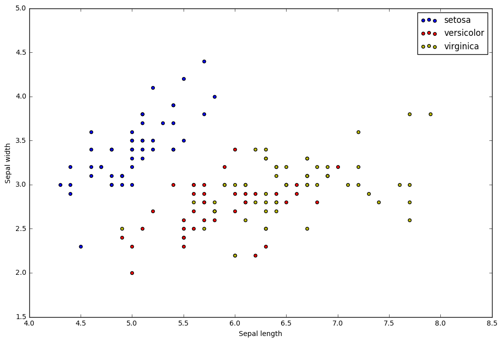

```python
import matplotlib.pyplot as plt

fig = plt.figure(figsize=(12,8))
colors = "bry"
for i in range(len(colors)):
    xs = X_iris[:, 0][y_iris == i]
    ys = X_iris[:, 1][y_iris == i]
    plt.scatter(xs, ys, c=colors[i])
plt.legend(iris.target_names)
plt.xlabel('Sepal length')
plt.ylabel('Sepal width')
```

- First we'll need to shuffle the data, because samples with the same labels are continuous.

```python
idx = np.arange(X_iris.shape[0])
np.random.seed(13)
np.random.shuffle(idx)
X = X_iris[:, :2] # take only sepal length and width
X = X[idx]
y = y_iris[idx]
```

- Stochastic Gradient Descent is sensitive to feature scaling, so it is highly recommended to scale our data.
- In particular we should scale each attribute on the input vector `X` to `[0,1]` or `[-1,+1]`, or standardise it to have mean 0 and variance 1; various Machine Learning methods assume that data have that mean and variance.
- This can be easily done using `StandardScaler`.
- `StandarScaler` scales the data so that they have mean 0 and variance equal to 1.

```python
from sklearn.preprocessing import StandardScaler

scaler = StandardScaler()
scaler.fit(X)
X = scaler.transform(X)
```

- Now we can build our classifier.

```python
from sklearn.linear_model import SGDClassifier

clf = SGDClassifier(alpha=0.001, n_iter=100).fit(X, y)
```

- The resulf of the classification is in the `clf` object.
- Since we are trying to classify three classes, the `clf` object contains the information for the three lines that divide our data instances.

```python
clf.coef_
```

```
array([[-4.15181168,  2.07696312],
       [ 0.08196641, -1.19171515],
       [ 1.69361769,  0.0445216 ]])
```

```python
clf.intercept_
```

```
array([-2.68706676, -0.72485109, -0.87117313])
```

- That means that we have three lines that divide our hyperplane.

- To see the classification, we'll plot a mesh grid.
- The mesh grid will show the surfaces that correspond to the classification labels.

```python
h = .02  # step size in the mesh

sepal_length_min, sepal_length_max = X[:, 0].min() - 1, X[:, 0].max() + 1
sepal_width_min, sepal_width_max = X[:, 1].min() - 1, X[:, 1].max() + 1
xx, yy = np.meshgrid(np.arange(sepal_length_min, sepal_length_max, h),
                     np.arange(sepal_width_min, sepal_width_max, h))
```

- We'll then predict the classification labels for all the values in the mesh.
- To do that we need to flatten `xx` and `yy` and then zip them, so that we feed to `predict` an array containing pairs of sepal length and sepal width values.
- The decision is based on the distance between the classifier line and the instance.
- The `predict` method calculates the distance, between each observation and the line, and selects the class of the line with the largest distance.

```python
xx_yy = np.c_[xx.ravel(), yy.ravel()] # zip the xx and yy values
Z = clf.predict(xx_yy)
```

- Having done that we can now make a contour plot with the predicted classifications.
- We will also plot the dataset in the same plot.

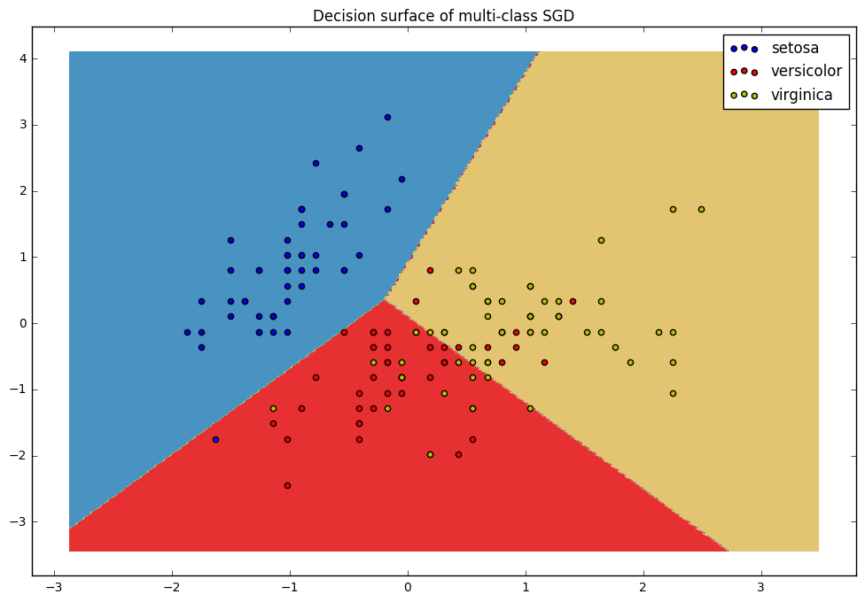

```python
fig = plt.figure(figsize=(12,8))
ax = fig.add_subplot(111)
Z = Z.reshape(xx.shape)
ax = fig.add_subplot(111)
ax.contourf(xx, yy, Z, cmap=plt.cm.Paired)

colors = "bry"
for i, color in zip(clf.classes_, colors):
    idx = np.where(y == i)
    ax.scatter(X[idx, 0], X[idx, 1], c=color, label=iris.target_names[i],
                cmap=plt.cm.Paired)

ax.set_title("Decision surface of multi-class SGD")
plt.axis('tight')
plt.legend()
```

- It is also a good idea to plot the "One-vs-All" (OvA), or equivalently "One-vs-Rest" (OvR) classifiers.
- These are the lines with the coefficients and intercepts we found in the classifier.

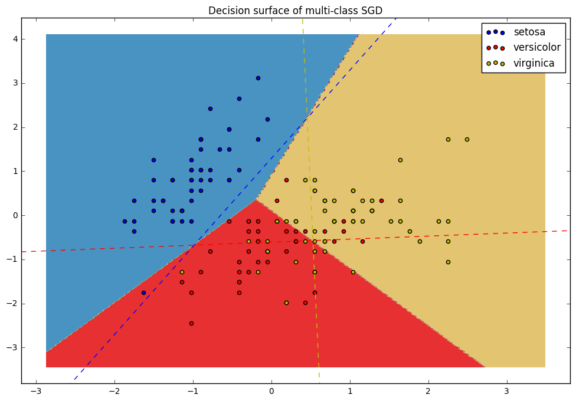

```python
fig = plt.figure(figsize=(12,8))
ax = fig.add_subplot(111)
Z = Z.reshape(xx.shape)
ax = fig.add_subplot(111)
ax.contourf(xx, yy, Z, cmap=plt.cm.Paired)

colors = "bry"
for i, color in zip(clf.classes_, colors):
    idx = np.where(y == i)
    ax.scatter(X[idx, 0], X[idx, 1], c=color, label=iris.target_names[i],
                cmap=plt.cm.Paired)

ax.set_title("Decision surface of multi-class SGD")
plt.axis('tight')

xmin, xmax = ax.get_xlim()
#ymin, ymax = ax.get_ylim()

coef = clf.coef_
intercept = clf.intercept_

for i, color in zip(clf.classes_, colors):
    ymin = (-(xmin * coef[i, 0]) - intercept[i]) / coef[i, 1]
    ymax = (-(xmax * coef[i, 0]) - intercept[i]) / coef[i, 1]
    ax.plot([xmin, xmax], [ymin, ymax],
             ls="--", color=color)
plt.legend()
```

# Evaluation

- In reality, we would probably *not* use all our training data set to fit the classifier.
- We would use a part of it for training, and a part of it to evaluate our classifier.

```python
from sklearn.model_selection import train_test_split
from sklearn import preprocessing

# Get dataset with only the first two attributes
X, y = X_iris[:, :2], y_iris

# Split the dataset into a training and a testing set
# Test set will be the 25% taken randomly
X_train, X_test, y_train, y_test = train_test_split(X, y, test_size=0.25, random_state=33)

print(X_train.shape, y_train.shape)
```

```
(112, 2) (112,)
```

```python
from sklearn.linear_model import SGDClassifier
clf = SGDClassifier(alpha=0.001, n_iter=100)
clf.fit(X_train, y_train)
```

```
SGDClassifier(alpha=0.001, average=False, class_weight=None, epsilon=0.1,
       eta0=0.0, fit_intercept=True, l1_ratio=0.15,
       learning_rate='optimal', loss='hinge', n_iter=100, n_jobs=1,
       penalty='l2', power_t=0.5, random_state=None, shuffle=True,
       verbose=0, warm_start=False)
```

- We can plot the lines and see if they correspond to good decision boundaries.

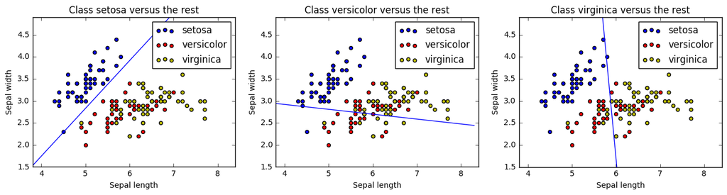

```python
x_min, x_max = X_train[:, 0].min() - .5, X_train[:, 0].max() + .5 # sepal length
y_min, y_max = X_train[:, 1].min() - .5, X_train[:, 1].max() + .5 # sepal width
xs = np.arange(x_min, x_max, 0.5)
fig, axes = plt.subplots(1, 3)
fig.set_size_inches(16, 10)

for i in clf.classes_:
    axes[i].set_aspect('equal')
    axes[i].set_title('Class '+ iris.target_names[i] + ' versus the rest')
    axes[i].set_xlabel('Sepal length')
    axes[i].set_ylabel('Sepal width')
    axes[i].set_xlim(x_min, x_max)
    axes[i].set_ylim(y_min, y_max)
    for j, color in zip(clf.classes_, colors):
        idx = np.where(y == j)
        axes[i].scatter(X[idx, 0], X[idx, 1], c=color, label=iris.target_names[j],
                        cmap=plt.cm.Paired)
    ys = (-clf.intercept_[i] - xs * clf.coef_[i, 0]) / clf.coef_[i, 1]
    axes[i].plot(xs, ys)
    axes[i].legend()
```

- A straightforward performance metric is *accuracy*: the proportion of instances correctly classified by the classifier.

```python
from sklearn import metrics
y_train_pred = clf.predict(X_train)
metrics.accuracy_score(y_train, y_train_pred)
```

```
0.8125
```

```python
y_pred = clf.predict(X_test)
metrics.accuracy_score(y_test, y_pred)
```

```
0.68421052631578949
```

$$H={\frac {n}{{\frac {1}{x_{1}}}+{\frac {1}{x_{2}}}+\cdots +{\frac {1}{x_{n}}}}}$$

- So, the $F_1$ score is:

$$F_{1}=2\cdot \frac{1}{\tfrac{1}{\mathrm{recall}}+\tfrac{1}{\mathrm{precision}}} = 2\cdot {\frac{\mathrm{precision} \cdot \mathrm{recall}}{\mathrm{precision} +\mathrm{recall}}}$$

```python
print(metrics.classification_report(y_test, y_pred, target_names=iris.target_names))
```

```
             precision    recall  f1-score   support

     setosa       1.00      1.00      1.00         8
 versicolor       0.40      0.18      0.25        11
  virginica       0.64      0.84      0.73        19

avg / total       0.65      0.68      0.65        38
```

- The support is the number of samples of the `y_test` dataset that lie in that class.
- Another useful metric is the *confusion matrix*.
- Each cell $(i, j)$ in the confusion matrix contains the number of instances of class $i$ that were predicted to be in class $j$.
- A good classifier will accumulate values on the diagonal.

```python
metrics.confusion_matrix(y_test, y_pred)
```

```
array([[ 8,  0,  0],
       [ 0,  2,  9],
       [ 0,  3, 16]])
```

- There is a way to improve the validation of our model, called *k-fold cross-validation*.
- In k-fold cross-validation, the original sample is randomly partitioned into $k$ equal sized subsamples.
- Of the $k$ subsamples, a single subsample is retained as the validation data for testing the model, and the remaining $k − 1$ subsamples are used as training data.
- The cross-validation process is then repeated $k$ times (the "folds"), with each of the $k$ subsamples used exactly once as the validation data.
- The $k$ results from the folds can then be averaged (or otherwise combined) to produce a single estimation.
- A variation of k-fold validation is *stratified k-fold validation*.
- It returns stratified folds, where each set contains approximately the same percentage of samples of each target class as the complete set.
- To simplify the whole process we'll use the `Pipeline` class.
- The construction of the `Pipeline` class takes a list of `(name, transform)` tuples (implementing fit/transform) that are chained, in the order in which they are chained, with the last object an estimator.
- In this way we'll combine the standard scaling and the classification.

```python
from sklearn.pipeline import Pipeline
from sklearn.preprocessing import StandardScaler

clf = Pipeline([
        ('scaler', StandardScaler()),
        ('linear_model', SGDClassifier())
    ])
```

- Now we can get our validation scores.
- We will use the `cross_val_score` method.
- The `cross_val_score` takes a `scoring` parameter that indicates the score to calculate. It can be one of:
  - `accuracy`
  - `recall`
  - `f1`
  - etc.
- It also takes a `cv` parameter. When it is an integer, it uses a k-fold strategy, or a stratifield k-fold strategy when the classifier is derived from `ClassifierMixin` (`SGDClassifier` is derived from `ClassifierMixin`).

```python
from sklearn.model_selection import cross_val_score

scores = cross_val_score(clf, X, y, cv=5, scoring='accuracy')
scores
```

```
array([ 0.7       ,  0.73333333,  0.7       ,  0.66666667,  0.63333333])
```

- From here we can obtain the mean and the standard error of the mean of the scores.

```python
from scipy.stats import sem

print(np.mean(scores), sem(scores))
```

```
0.686666666667 0.016996731712
```

# Principal Component Analysis

- Principal Component Analysis (PCA) is an important technique in Machine Learning, with many applications.
- The idea is to convert a set of observations of possibly correlated variables into a set of values of linearly uncorrelated variables called *principal components*.
- The number of principal components is less than the original number of variables.
- The idea is that with the principal components we can capture essential aspects of the variables that correspond to the principal components.
- Moreover, the principal components capture, in decreasing order, the variance exhibited by the original variables.
- So the first principal component is the most important in that it captures more variance than any other component, the second principal component is the second in importance because it captures more variance than any other component bar the first component, etc.
- PCA is a form of *unsupervised learning*, because we do not supply target values.
- PCA is therefore particularly useful for *dimensional reduction*.
- In dimensional reduction we want to reduce the number of dimensions that we handle (because the number is very big), yet without losing important information from our observations.
- To do that, we perform PCA and we select as many principal components as we need to retain the characteristics of the original dimensions.
- To see how this works, let's perform PCA on an image.
- We are going to use an iconic image, [Dorothea Lange's photo of the migrant mother](https://en.wikipedia.org/wiki/Florence_Owens_Thompson).
- This image is not already contained in scikit-learn, so we'll have to import it.
- We need to install the Python Imaging Library for that.
- We can do that with `pip3 install pillow`.
- Then we read and display the image.

[figure not shown]

```python
from PIL import Image

img = Image.open("lange_migrant_mother.jpg")

def show_image(img, h, w, size):
    plt.figure(figsize=(12, 10))
    plt.xticks(())
    plt.yticks(())
    plt.imshow(img,  cmap=plt.cm.gray)
    plt.title("height: %s width: %s size: %s" % (h, w, size))

show_image(img, img.size[1], img.size[0], img.size[0] * img.size[1])
```

- Now we can convert the image to the format that scikit-learn understands.
- Remember that scikit-learn needs an `n_samples`, `n_features` array.
- We'll therefore create an array whose rows will be horizontal lines of the picture and columns will be vertical lines.

```python
print(img.size)
image_array = np.array(img.getdata(),
                       np.uint8).reshape((img.size[1], img.size[0]))
print(image_array.shape)
```

```
(692, 900)
(900, 692)
```

- PCA is implemented through the `PCA` class and its subclasses.
- We instantiate an estimator and then we fit with our data.
- We treat our image as our dataset, having 692 features (our columns).
- We'll perform PCA with 50 components.
- In effect, we'll try to reduce the image so it is represented as an orthogonal transformation of the data using 50 components instead of the 692 original ones.

```python
from sklearn.decomposition import PCA

n_components=50

pca = PCA(n_components=n_components)
pca.fit(image_array)
```

```
PCA(copy=True, iterated_power='auto', n_components=50, random_state=None,
  svd_solver='auto', tol=0.0, whiten=False)
```

- What have we done?
- We have found the 50 principal components of our image.
- Each component is a row (692 pixels).

```python
pca.components_.shape
```

```
(50, 692)
```

- So, instead of the original set of 900 rows, our image can be produced (or rather, approximated), by a linear combination of the 50 rows we found.
- We can easily see the explained variance ratio of each component.

```python
pca.explained_variance_ratio_
```

```
array([ 0.47304963,  0.1281772 ,  0.09398614,  0.05163205,  0.03208675,
        0.02249176,  0.01838176,  0.01489537,  0.01297648,  0.01056557,
        0.00931143,  0.00778975,  0.00703793,  0.00594134,  0.00562516,
        0.00547761,  0.00486829,  0.00431924,  0.00401961,  0.00366617,
        0.00330617,  0.00303809,  0.00289611,  0.00251274,  0.00239563,
        0.00222432,  0.00201078,  0.00197097,  0.00185998,  0.00182421,
        0.00169807,  0.0016067 ,  0.00152938,  0.00150396,  0.00145237,
        0.00135394,  0.00120389,  0.00118385,  0.00117508,  0.0011261 ,
        0.00111496,  0.00108892,  0.00103306,  0.0009716 ,  0.0009138 ,
        0.00091061,  0.00087801,  0.00086637,  0.00082625,  0.00080495])
```

- How do the principal components look like?
- Let's see them.

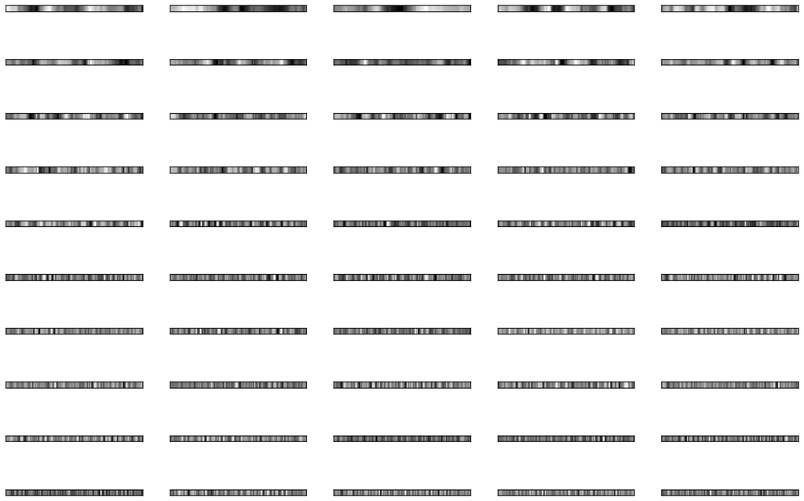

```python
row_width = 30
plt.figure(figsize=(2 * 1.8 * 5, 2 * 1.2 * 5))
for component in range(pca.components_.shape[0]):
    plt.subplot(pca.components_.shape[0] // 5, 5, component + 1)
    comp_row = np.tile(pca.components_[component], row_width).reshape((row_width, -1))
    plt.imshow(comp_row, cmap=plt.cm.gray)
    plt.xticks(())
    plt.yticks(())
```

- Now we can project the original image on these components.

```python
image_pca = pca.transform(image_array)
print(image_pca.shape)
```

```
(900, 50)
```

- The `image_pca` array is the result of the following transformation:

$$ X P = Y $$

- In the above formula, $P$ is a matrix containing the components we have found as columns, $X$ is a matrix containing our original data, and $Y$ is `image_pca`.
- Since $X$ is a matrix with dimensions `n_samples`, `n_features` and $P$ is a matrix with dimensions `n_features`, `n_components`, $Y$ is a matrix with dimensions `n_samples`, `n_components`.
- If we were to display the projection we would see a reduced image that, however, explains the variance of the 50 principal components of the original image.

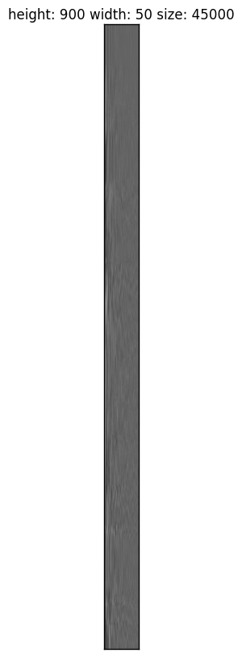

```python
show_image(image_pca, image_pca.shape[0], image_pca.shape[1], image_pca.size)
```

- Although the above does not look like much, we can verify that it contains much of the information of the original image.
- We can project the PCA image back to the original space by `inverse_transform` method.
- So, the PCA image is a compressed version of the original image
- Note that when we project back to the original space we return to the original image size, but below we display the PCA image size because that is what we have actually kept.

[figure not shown]

```python
image_pca = pca.transform(image_array)
reduced_image = pca.inverse_transform(image_pca)
show_image(reduced_image, reduced_image.shape[0], reduced_image.shape[1], image_pca.size)
```

- We can also see how much information is lost with different choices of the numbers of principal components.

[figure not shown]

```python
plt.figure(figsize=(2 * 1.8 * 5, 2 * 2.4 * 5))
for n_components in range(1, 51, 5):
    pca = PCA(n_components=n_components).fit(image_array)
    image_pca = pca.transform(image_array)
    plt.subplot(5, 5, 1 + n_components // 5)
    plt.imshow(pca.inverse_transform(image_pca), cmap=plt.cm.gray)
    title = 'components: %s\nsize: %s' % (n_components, image_pca.size)
    plt.title(title, size=12)
    plt.xticks(())
    plt.yticks(())
```

# Face Recognition with Support Vector Machines

- The dataset used in this example is a preprocessed excerpt of the “Labeled Faces in the Wild”, aka LFW: http://vis-www.cs.umass.edu/lfw/lfw-funneled.tgz (233MB).
- We are interested in identifying the seven most represented people in this dataset. These people are:
  - Ariel Sharon
  - Colin Powell
  - Donald Rumsfeld
  - George W Bush
  - Gerhard Schroeder
  - Hugo Chavez
  - Tony Blair
- Let's download the data, if not already on disk, and load it as numpy arrays.

```python
from sklearn.datasets import fetch_lfw_people

lfw_people = fetch_lfw_people(min_faces_per_person=70, resize=0.4)
```

- Once we have the data, we are going to peek into it to get the number of the samples and the dimensions of the images, which we'll use for plotting.

```python
n_samples, h, w = lfw_people.images.shape

print("n_samples:", n_samples)
print("height of each image:", h)
print("width of each image:", w)
```

```
n_samples: 1288
height of each image: 50
width of each image: 37
```

- We also need to get the actual data and the number of features.

```python
X = lfw_people.data
n_features = X.shape[1]

print("n_features: ", n_features)
```

```
n_features:  1850
```

- We can verify that the number of features is the number of pixels in the image, `h * w`.
- We need the target and the target names, which is just the ID of each person. Then the number of classes is the number of names.

```python
y = lfw_people.target
target_names = lfw_people.target_names
n_classes = target_names.shape[0]

print("n_classes:", n_classes)
```

```
n_classes: 7
```

```python
X_train, X_test, y_train, y_test = train_test_split(
    X, y, test_size=0.25, random_state=42)
```

- The first step in our analysis is to perform dimensionality reduction.
- We'll do that to reduce the number of portraits from the original 1288 to the more manageable 150.
- The idea is that instead of the original portraits, we will have 150 portraits; the original portraits (or rather, approximations of them) will be produced as a linear combination of the 150 portraits we will find.

```python
from sklearn.decomposition import PCA

n_components = 150
pca = PCA(n_components=n_components, svd_solver='randomized', whiten=True).fit(X_train)
```

- We'll get the eigenfaces.
- The eigenfaces are the principal components reshaped as portraits.

```python
print(pca.components_.shape)
eigenfaces = pca.components_.reshape((n_components, h, w))
print(eigenfaces.shape)
```

```
(150, 1850)
(150, 50, 37)
```

- We'll also define a function to plot images.

```python
def plot_gallery(images, titles, h, w, n_row=3, n_col=4):
    """Helper function to plot a gallery of portraits"""
    plt.figure(figsize=(1.8 * n_col, 2.4 * n_row))
    plt.subplots_adjust(bottom=0, left=.01, right=.99, top=.90, hspace=.35)
    for i in range(n_row * n_col):
        plt.subplot(n_row, n_col, i + 1)
        plt.imshow(images[i].reshape((h, w)), cmap=plt.cm.gray)
        plt.title(titles[i], size=12)
        plt.xticks(())
        plt.yticks(())
```

- Using this function we can plot the eigenfaces we got.

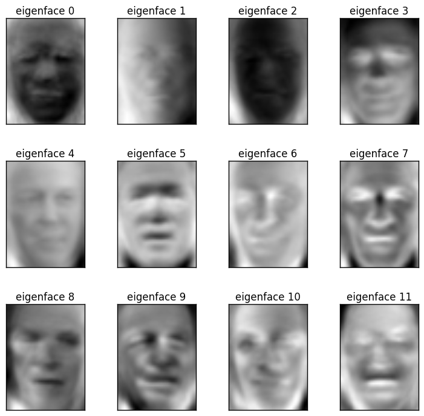

```python
eigenface_titles = ["eigenface %d" % i for i in range(eigenfaces.shape[0])]
plot_gallery(eigenfaces, eigenface_titles, h, w)
```

- Next, we project the input data on the eigenfaces orthonormal basis.

```python
X_train_pca = pca.transform(X_train)
X_test_pca = pca.transform(X_test)
```

- With that in place, we can train a SVM classification model and fit the classifier to the training set.
- The training set will, of course, be the one we got with PCA.
- One of the tricky things with Machine Learning, and SVM, is knowing which parameter values to use for an estimator.
- We can put scikit-learn to do the work for us by using the `GridSearchCV` class.
- The `GridSearchCV` instance evaluates all the possible combinations of parameter values and retains the best combination.
- By default, the parameter search uses the `score` function of the estimator to evaluate a parameter setting, but we can change that if we want.

```python
from sklearn.model_selection import GridSearchCV
from sklearn.svm import SVC

param_grid = {'C': [1e3, 5e3, 1e4, 5e4, 1e5],
              'gamma': [0.0001, 0.0005, 0.001, 0.005, 0.01, 0.1], }
clf = GridSearchCV(SVC(kernel='rbf', class_weight='balanced'), param_grid)
clf = clf.fit(X_train_pca, y_train)
clf.best_estimator_
```

[output not shown]

- We'll use the classifier to predict the target values for the test data.

```python
y_pred = clf.predict(X_test_pca)
```

- Let's see the classification report.

```python
from sklearn.metrics import classification_report

print(classification_report(y_test, y_pred, target_names=target_names))
```

[output not shown]

- And let's see the confusion matrix.

```python
from sklearn.metrics import confusion_matrix

print(confusion_matrix(y_test, y_pred, labels=range(n_classes)))
```

[output not shown]

- To plot the prediction results we'll use a helper function to give us the title of each image.

```python
def title(y_pred, y_test, target_names, i):
    pred_name = target_names[y_pred[i]].rsplit(' ', 1)[-1]
    true_name = target_names[y_test[i]].rsplit(' ', 1)[-1]
    return 'predicted: %s\ntrue:      %s' % (pred_name, true_name)

prediction_titles = [title(y_pred, y_test, target_names, i)
                     for i in range(y_pred.shape[0])]
```

- And now we can plot part of the results of the test set.

```python
plot_gallery(X_test, prediction_titles, h, w)
```

[output not shown]